# Overview

## Hofstede’s Dimensions

Author’s note: This work was performed as part of the Developing Data Skills course at the University of Edinburgh in spring 2021. Though effort was made to adequately research the background and theory behind the data studied, the author has no background in sociology and is ill-equipped to accurately evaluate the findings. As such, this work should be regarded as an exercise in data analysis and no real-world conclusions should be inferred.

## Introduction

Geert Hofstede founded the personnel research department at IBM Europe in 1961, and between 1967 and 1973 conducted a large-scale worldwide survey of IBM employees for the purposes of determining difference in attitude across nations. These attitudes were initially categorised along four cultural dimensions: *power distance, individualism, uncertainty avoidance, and masculinity*. This work was published in his 1980 book *Culture’s Consequences* [1] and was intended to inform IBM’s policy regarding how to adapt management techniques and work environments across their global operation. Note that these cultural dimensions are equivalently referred to as cultural indices. Since then, these dimensions have formed a basic framework for cross-cultural studies and have been augmented to include the dimensions *long-term orientation* and *indulgence* where added following work performed by Michael Minkov [2], [3]. The work of Hofstede is today carried out by the Hofstede Institute which continues to study and refine the various indices (https://www.hofstede-insights.com).

Hofstede’s work is not without criticism. For instance, it has been proposed that a false equivalency is drawn between culture and nation, with many nations containing pronounced subcultures with significantly different values and attitudes [4]. Furthermore, while Hofstede makes it clear that no value-judgement is being made regarding the cultural dimensions [1], it has been argued that the lack of diversity on his research team resulted in an analysis that is inevitable white, male and Eurocentric [5]. The initial study was also accused of lacking rigor and containing too small sample sizes to draw conclusions regarding entire nations, with no consideration given to whether the sample was representative of the nation as a whole [6].

Nonetheless, his seminal work remains the most cited publication in the field of cross-cultural psychology [7] and has been widely applied since its publication (see [8], [9], [10] and references therein) and has been heralded even by its critics as “a super classic” [11]. The ambition of this project is to explore particularly pronounced cultural differences between countries and to examine correlations between these dimensions. In particular, the question prompting this analysis was “Which border, when crossed, gives one the largest culture shock?” where the culture shock will be assumed to be proportional to the difference in the cultural dimensions.

## The Dimensions and Definitions

1. Power Distance: the extent to which less powerful members of an organisation or institution accept and expect that power is distributed unequally. Examples of lower power distance behaviour are irreverence for authority figures and more equal income distributions, whereas high power distance is characterised by strong societal hierarchies.
2. Uncertainty Avoidance: the extent to which individuals feel uncomfortable or comfortable in unstructured and unfamiliar situations. A high uncertainty avoidance is characterised by stricter behaviour codes and laws, and a disapproval of deviation. A low uncertainty avoidance results in a dislike of rules and acceptance of diverse moral and political frameworks.
3. Individualism: individualism is opposed to collectivism and characterises the degree to which people in a society are integrated into groups such as family or the state. High collectivism is characterised belonging, harmony, and contribution to the group rather than individual priority and achievement.
4. Masculinity: masculinity as opposed to femininity can be thought of the extent to which a country takes an egalitarian or feminist approach to societal structures; feminine/feminist societies tend to afford strong work-family balance, reduced segregation between male and female spaces, and promote women in positions of authority and power.
5. Long-term orientation: this dimension characterises the propensity to maintain time-honoured traditions and norms while viewing societal change with suspicions. Short-term orientation is characterised by showing an ability to easily adapt traditions to changing conditions.
6. Indulgence: People in societies classified by a high score in Indulgence generally exhibit a willingness to realise their impulses and desires regarding enjoying life and having fun. A low-indulgence society is characterized by restraint, putting less emphasis on leisure time and gratification.

## References

1. G. H. Hofstede, Culture’s Consequences: International Differences in Work-Related Values, 1st ed. in Cross Cultural Research and Methodology. SAGE Publications, 1980.
2. M. Minkov and G. Hofstede, ‘Hofstede’s fifth dimension: New evidence from the world values survey’, Journal of Cross-Cultural Psychology, vol. 43, no. 1, pp. 3–14, 2012, doi: 10.1177/0022022110388567.
3. G. Hofstede, ‘Dimensionalizing Cultures: The Hofstede Model in Context’, Online Readings in Psychology and Culture, vol. 2, no. 1, pp. 1–26, 2011, doi: 10.9707/2307-0919.1014.
4. B. McSweeney, ‘Hofstede’s model of national cultural differences and their consequences: A triumph of faith - A failure of analysis’, Human Relations, vol. 55, no. 1, pp. 89–118, Jan. 2002, doi: 10.1177/0018726702551004.
5. K. E. Ferguson, ‘On Bringing More Theory, More Voices and More Politics to the Study of Organization’, Organization, vol. 1, no. 1, pp. 81–99, Jul. 1994, doi: 10.1177/135050849400100112.
6. G. Ailon, ‘Mirror, mirror on the wall: Culture’s consequences in a value test of its own design’, Academy of Management Review, vol. 33, no. 4, pp. 885–904, 2008, doi: 10.5465/AMR.2008.34421995.
7. M. H. Bond, ‘Reclaiming the individual from Hofstede’s ecological analysis - A 20-year odyssey: Comment on Oyserman et al. (2002)’, Psychological Bulletin, vol. 128, no. 1, pp. 73–77, 2002, doi: 10.1037/0033-2909.128.1.73.
8. M. Søndergaard, ‘Research Note: Hofstede’s Consequences: A Study of Reviews, Citations and Replications’, Organization Studies, vol. 15, no. 3, pp. 447–456, May 1994, doi: 10.1177/017084069401500307.
9. M. L. Jones, ‘Hofstede - Culturally questionable?’, in Oxford Business & Economics Conference, Oxford, UK, 2007.
10. B. L. Kirkman, K. B. Lowe, and C. B. Gibson, ‘A quarter century of culture’s consequences: A review of empirical research incorporating Hofstede’s cultural values framework’, Journal of International Business Studies, vol. 37, no. 3, pp. 285–320, 2006, doi: 10.1057/palgrave.jibs.8400202.
11. R. F. Baskerville, ‘Hofstede never studied culture’, Accounting, Organizations and Society, vol. 28, no. 1, pp. 1–14, Jan. 2003, doi: 10.1016/S0361-3682(01)00048-4.

# Land Borders

First off, we'll need to check which countries border which. To do this, we'll use the GeoPandas Natural Earth dataset, and find borders by check for intersections between the country geometries.

```python
import geopandas as gp
import numpy as np
from geodatasets import get_path
import pandas as pd
```

## Load Data

```python
world_full = gp.read_file('ne_110m_admin_0_countries/ne_110m_admin_0_countries.dbf')
world_full.to_crs('4326')
world_full.head()
```

|  | featurecla | scalerank | LABELRANK | SOVEREIGNT | SOV_A3 | ADM0_DIF | LEVEL | TYPE | TLC | ADMIN | ... | FCLASS_TR | FCLASS_ID | FCLASS_PL | FCLASS_GR | FCLASS_IT | FCLASS_NL | FCLASS_SE | FCLASS_BD | FCLASS_UA | geometry |
| --- | --- | --- | --- | --- | --- | --- | --- | --- | --- | --- | --- | --- | --- | --- | --- | --- | --- | --- | --- | --- | --- |
| 0 | Admin-0 country | 1 | 6 | Fiji | FJI | 0 | 2 | Sovereign country | 1 | Fiji | ... | None | None | None | None | None | None | None | None | None | MULTIPOLYGON (((180.00000 -16.06713, 180.00000... |
| 1 | Admin-0 country | 1 | 3 | United Republic of Tanzania | TZA | 0 | 2 | Sovereign country | 1 | United Republic of Tanzania | ... | None | None | None | None | None | None | None | None | None | POLYGON ((33.90371 -0.95000, 34.07262 -1.05982... |
| 2 | Admin-0 country | 1 | 7 | Western Sahara | SAH | 0 | 2 | Indeterminate | 1 | Western Sahara | ... | Unrecognized | Unrecognized | Unrecognized | None | None | Unrecognized | None | None | None | POLYGON ((-8.66559 27.65643, -8.66512 27.58948... |
| 3 | Admin-0 country | 1 | 2 | Canada | CAN | 0 | 2 | Sovereign country | 1 | Canada | ... | None | None | None | None | None | None | None | None | None | MULTIPOLYGON (((-122.84000 49.00000, -122.9742... |
| 4 | Admin-0 country | 1 | 2 | United States of America | US1 | 1 | 2 | Country | 1 | United States of America | ... | None | None | None | None | None | None | None | None | None | MULTIPOLYGON (((-122.84000 49.00000, -120.0000... |

5 rows × 169 columns

This is a bit weird. The SOV_A3 code, which I thought was the ISO code, for the United States of America is US1. I know for a fact that the ISO code is in fact USA. What's going on here?

```python
world_full.columns.to_list()
```

```
['featurecla',
 'scalerank',
 'LABELRANK',
 'SOVEREIGNT',
 'SOV_A3',
 'ADM0_DIF',
 'LEVEL',
 'TYPE',
 'TLC',
 'ADMIN',
 'ADM0_A3',
 'GEOU_DIF',
 'GEOUNIT',
 'GU_A3',
 'SU_DIF',
 'SUBUNIT',
 'SU_A3',
 'BRK_DIFF',
 'NAME',
 'NAME_LONG',
 'BRK_A3',
 'BRK_NAME',
 'BRK_GROUP',
 'ABBREV',
 'POSTAL',
 'FORMAL_EN',
 'FORMAL_FR',
 'NAME_CIAWF',
 'NOTE_ADM0',
 'NOTE_BRK',
 'NAME_SORT',
 'NAME_ALT',
 'MAPCOLOR7',
 'MAPCOLOR8',
 'MAPCOLOR9',
 'MAPCOLOR13',
 'POP_EST',
 'POP_RANK',
 'POP_YEAR',
 'GDP_MD',
```

[output cut: 114 more lines]

```
 'FCLASS_PT',
 'FCLASS_AR',
 'FCLASS_JP',
 'FCLASS_KO',
 'FCLASS_VN',
 'FCLASS_TR',
 'FCLASS_ID',
 'FCLASS_PL',
 'FCLASS_GR',
 'FCLASS_IT',
 'FCLASS_NL',
 'FCLASS_SE',
 'FCLASS_BD',
 'FCLASS_UA',
 'geometry']
```

Got it, there are more columns, including an ISO_A3. We'll work with that.

```python
world_full.ISO_A3
```

```
0      FJI
1      TZA
2      ESH
3      CAN
4      USA
      ...
172    SRB
173    MNE
174    -99
175    TTO
176    SSD
Name: ISO_A3, Length: 177, dtype: object
```

We can drop most of the columns.

```python
world = world_full[['ISO_A3_EH', 'NAME_EN', 'SOVEREIGNT', 'HOMEPART', 'geometry']]
world
```

|  | ISO_A3_EH | NAME_EN | SOVEREIGNT | HOMEPART | geometry |
| --- | --- | --- | --- | --- | --- |
| 0 | FJI | Fiji | Fiji | 1 | MULTIPOLYGON (((180.00000 -16.06713, 180.00000... |
| 1 | TZA | Tanzania | United Republic of Tanzania | 1 | POLYGON ((33.90371 -0.95000, 34.07262 -1.05982... |
| 2 | ESH | Western Sahara | Western Sahara | 1 | POLYGON ((-8.66559 27.65643, -8.66512 27.58948... |
| 3 | CAN | Canada | Canada | 1 | MULTIPOLYGON (((-122.84000 49.00000, -122.9742... |
| 4 | USA | United States of America | United States of America | 1 | MULTIPOLYGON (((-122.84000 49.00000, -120.0000... |
| ... | ... | ... | ... | ... | ... |
| 172 | SRB | Serbia | Republic of Serbia | 1 | POLYGON ((18.82982 45.90887, 18.82984 45.90888... |
| 173 | MNE | Montenegro | Montenegro | 1 | POLYGON ((20.07070 42.58863, 19.80161 42.50009... |
| 174 | -99 | Kosovo | Kosovo | 1 | POLYGON ((20.59025 41.85541, 20.52295 42.21787... |
| 175 | TTO | Trinidad and Tobago | Trinidad and Tobago | 1 | POLYGON ((-61.68000 10.76000, -61.10500 10.890... |
| 176 | SSD | South Sudan | South Sudan | 1 | POLYGON ((30.83385 3.50917, 29.95350 4.17370, ... |

177 rows × 5 columns

I've kept HOMEPART because for our analysis, I'm thinking that these don't really count as representative of the SOVEREIGNT culture.

```python
world[world['HOMEPART']!=1]
```

|  | ISO_A3_EH | NAME_EN | SOVEREIGNT | HOMEPART | geometry |
| --- | --- | --- | --- | --- | --- |
| 20 | FLK | Falkland Islands | United Kingdom | -99 | POLYGON ((-61.20000 -51.85000, -60.00000 -51.2... |
| 22 | GRL | Greenland | Denmark | -99 | POLYGON ((-46.76379 82.62796, -43.40644 83.225... |
| 23 | ATF | French Southern and Antarctic Lands | France | -99 | POLYGON ((68.93500 -48.62500, 69.58000 -48.940... |
| 45 | PRI | Puerto Rico | United States of America | -99 | POLYGON ((-66.28243 18.51476, -65.77130 18.426... |
| 79 | PSE | Palestine | Israel | -99 | POLYGON ((35.39756 31.48909, 34.92741 31.35344... |
| 134 | NCL | New Caledonia | France | -99 | POLYGON ((165.77999 -21.08000, 166.59999 -21.7... |

As suspected, I don't think these should be included.

```python
world = world.drop(world[world['HOMEPART']!=1].index).drop('HOMEPART', axis=1)
world
```

|  | ISO_A3_EH | NAME_EN | SOVEREIGNT | geometry |
| --- | --- | --- | --- | --- |
| 0 | FJI | Fiji | Fiji | MULTIPOLYGON (((180.00000 -16.06713, 180.00000... |
| 1 | TZA | Tanzania | United Republic of Tanzania | POLYGON ((33.90371 -0.95000, 34.07262 -1.05982... |
| 2 | ESH | Western Sahara | Western Sahara | POLYGON ((-8.66559 27.65643, -8.66512 27.58948... |
| 3 | CAN | Canada | Canada | MULTIPOLYGON (((-122.84000 49.00000, -122.9742... |
| 4 | USA | United States of America | United States of America | MULTIPOLYGON (((-122.84000 49.00000, -120.0000... |
| ... | ... | ... | ... | ... |
| 172 | SRB | Serbia | Republic of Serbia | POLYGON ((18.82982 45.90887, 18.82984 45.90888... |
| 173 | MNE | Montenegro | Montenegro | POLYGON ((20.07070 42.58863, 19.80161 42.50009... |
| 174 | -99 | Kosovo | Kosovo | POLYGON ((20.59025 41.85541, 20.52295 42.21787... |
| 175 | TTO | Trinidad and Tobago | Trinidad and Tobago | POLYGON ((-61.68000 10.76000, -61.10500 10.890... |
| 176 | SSD | South Sudan | South Sudan | POLYGON ((30.83385 3.50917, 29.95350 4.17370, ... |

171 rows × 4 columns

Lastly, check what's going on with there numerical ISO-codes.

```python
world[world.ISO_A3_EH.apply(lambda x: any(char.isdigit() for char in x))]
```

|  | ISO_A3_EH | NAME_EN | SOVEREIGNT | geometry |
| --- | --- | --- | --- | --- |
| 160 | -99 | Turkish Republic of Northern Cyprus | Northern Cyprus | POLYGON ((32.73178 35.14003, 32.80247 35.14550... |
| 167 | -99 | Somaliland | Somaliland | POLYGON ((48.94820 11.41062, 48.94820 11.41062... |
| 174 | -99 | Kosovo | Kosovo | POLYGON ((20.59025 41.85541, 20.52295 42.21787... |

Right, so these are clearly edge cases of states with limited recognition. For our purposes, we'll ignore them because the cultural data doesn't exist for them.

```python
world = world.drop(world[world.ISO_A3_EH.apply(lambda x: any(char.isdigit() for char in x))].index).reset_index(drop=True)
world
```

|  | ISO_A3_EH | NAME_EN | SOVEREIGNT | geometry |
| --- | --- | --- | --- | --- |
| 0 | FJI | Fiji | Fiji | MULTIPOLYGON (((180.00000 -16.06713, 180.00000... |
| 1 | TZA | Tanzania | United Republic of Tanzania | POLYGON ((33.90371 -0.95000, 34.07262 -1.05982... |
| 2 | ESH | Western Sahara | Western Sahara | POLYGON ((-8.66559 27.65643, -8.66512 27.58948... |
| 3 | CAN | Canada | Canada | MULTIPOLYGON (((-122.84000 49.00000, -122.9742... |
| 4 | USA | United States of America | United States of America | MULTIPOLYGON (((-122.84000 49.00000, -120.0000... |
| ... | ... | ... | ... | ... |
| 163 | MKD | North Macedonia | North Macedonia | POLYGON ((22.38053 42.32026, 22.88137 41.99930... |
| 164 | SRB | Serbia | Republic of Serbia | POLYGON ((18.82982 45.90887, 18.82984 45.90888... |
| 165 | MNE | Montenegro | Montenegro | POLYGON ((20.07070 42.58863, 19.80161 42.50009... |
| 166 | TTO | Trinidad and Tobago | Trinidad and Tobago | POLYGON ((-61.68000 10.76000, -61.10500 10.890... |
| 167 | SSD | South Sudan | South Sudan | POLYGON ((30.83385 3.50917, 29.95350 4.17370, ... |

168 rows × 4 columns

## Get Borders

### Testing Norway-Sweden Border

```python
world[world.ISO_A3_EH.isin(['SWE', 'NOR'])]
```

|  | ISO_A3_EH | NAME_EN | SOVEREIGNT | geometry |
| --- | --- | --- | --- | --- |
| 20 | NOR | Norway | Norway | MULTIPOLYGON (((15.14282 79.67431, 15.52255 80... |
| 105 | SWE | Sweden | Sweden | POLYGON ((11.02737 58.85615, 11.46827 59.43239... |

```python
sweden = world[world.ISO_A3_EH=='SWE'].reset_index(drop = True)
norway = world[world.ISO_A3_EH=='NOR'].reset_index(drop = True)
sweden.geometry.intersects(norway.geometry) # quick check that Norways does indeed intersect Sweden
```

```
0    True
dtype: bool
```

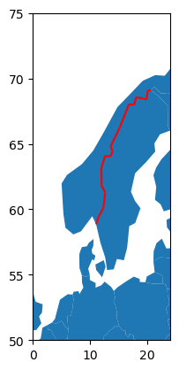

```python
# check border intersection
nor_swe_border = sweden.geometry.intersection(norway.geometry)
# plot border
ax = world.plot()
nor_swe_border.plot(ax=ax, color='r')
_ = ax.set_xlim(0, 24)
_ = ax.set_ylim(50, 75)
```

### Get All Boarders

```python
border_matrix = world.geometry.apply(lambda x: x.intersects(world.geometry))
border_matrix
```

|  | 0 | 1 | 2 | 3 | 4 | 5 | 6 | 7 | 8 | 9 | ... | 158 | 159 | 160 | 161 | 162 | 163 | 164 | 165 | 166 | 167 |
| --- | --- | --- | --- | --- | --- | --- | --- | --- | --- | --- | --- | --- | --- | --- | --- | --- | --- | --- | --- | --- | --- |
| 0 | True | False | False | False | False | False | False | False | False | False | ... | False | False | False | False | False | False | False | False | False | False |
| 1 | False | True | False | False | False | False | False | False | False | False | ... | False | False | True | True | False | False | False | False | False | False |
| 2 | False | False | True | False | False | False | False | False | False | False | ... | False | False | False | False | False | False | False | False | False | False |
| 3 | False | False | False | True | True | False | False | False | False | False | ... | False | False | False | False | False | False | False | False | False | False |
| 4 | False | False | False | True | True | False | False | False | False | False | ... | False | False | False | False | False | False | False | False | False | False |
| ... | ... | ... | ... | ... | ... | ... | ... | ... | ... | ... | ... | ... | ... | ... | ... | ... | ... | ... | ... | ... | ... |
| 163 | False | False | False | False | False | False | False | False | False | False | ... | False | False | False | False | False | True | True | False | False | False |
| 164 | False | False | False | False | False | False | False | False | False | False | ... | False | False | False | False | True | True | True | True | False | False |
| 165 | False | False | False | False | False | False | False | False | False | False | ... | False | False | False | False | True | False | True | True | False | False |
| 166 | False | False | False | False | False | False | False | False | False | False | ... | False | False | False | False | False | False | False | False | True | False |
| 167 | False | False | False | False | False | False | False | False | False | False | ... | True | False | True | False | False | False | False | False | False | True |

168 rows × 168 columns

```python
# diagonal values are obviously 'self-borders' so manually exclude these
np.fill_diagonal(border_matrix.values, False)
```

Go back to Sweden as an example

```python
# Sweden is index 105
world.iloc[border_matrix.iloc[105][border_matrix.iloc[105]].index]
```

|  | ISO_A3_EH | NAME_EN | SOVEREIGNT | geometry |
| --- | --- | --- | --- | --- |
| 20 | NOR | Norway | Norway | MULTIPOLYGON (((15.14282 79.67431, 15.52255 80... |
| 145 | FIN | Finland | Finland | POLYGON ((28.59193 69.06478, 28.44594 68.36461... |

This looks good. Let's continue and apply this to all countries.

```python
borders = border_matrix.apply(lambda x: x[x].index.tolist())
borders
```

```
0                                       []
1       [11, 13, 66, 67, 68, 71, 160, 161]
2                            [49, 77, 155]
3                                      [4]
4                                  [3, 24]
                      ...
163                   [117, 118, 120, 164]
164    [110, 112, 117, 121, 162, 163, 165]
165                   [120, 121, 162, 164]
166                                     []
167             [11, 13, 14, 62, 158, 160]
Length: 168, dtype: object
```

Now we just have to explode these and join them back onto an ISO code DataFrame.

```python
exp_borders = borders.explode()
```

```python
iso_borders = pd.DataFrame(exp_borders, columns=['bordering']).join(
                                                                world[['ISO_A3_EH', 'NAME_EN', 'geometry']]).join(
                                                                                                    world[['ISO_A3_EH', 'NAME_EN', 'geometry']],
                                                                                                    on='bordering',
                                                                                                    lsuffix='_country1',
                                                                                                    rsuffix='_country2')
```

```python
# tidy up
iso_borders = iso_borders.drop(['bordering'], axis=1).reset_index(drop=True)
# might as well add the actual border geometry also
iso_borders['geometry_border'] = iso_borders.apply(lambda x: x.geometry_country1.intersection(x.geometry_country2), axis=1)
iso_borders.head(10)
```

|  | ISO_A3_EH_country1 | NAME_EN_country1 | geometry_country1 | ISO_A3_EH_country2 | NAME_EN_country2 | geometry_country2 | geometry_border |
| --- | --- | --- | --- | --- | --- | --- | --- |
| 0 | FJI | Fiji | MULTIPOLYGON (((180.00000 -16.06713, 180.00000... | NaN | NaN | None | None |
| 1 | TZA | Tanzania | POLYGON ((33.90371 -0.95000, 34.07262 -1.05982... | COD | Democratic Republic of the Congo | POLYGON ((29.34000 -4.49998, 29.51999 -5.41998... | MULTILINESTRING ((30.740009731422095 -8.340005... |
| 2 | TZA | Tanzania | POLYGON ((33.90371 -0.95000, 34.07262 -1.05982... | KEN | Kenya | POLYGON ((39.20222 -4.67677, 37.76690 -3.67712... | MULTILINESTRING ((33.90371119710453 -0.9500000... |
| 3 | TZA | Tanzania | POLYGON ((33.90371 -0.95000, 34.07262 -1.05982... | ZMB | Zambia | POLYGON ((30.74001 -8.34001, 31.15775 -8.59458... | MULTILINESTRING ((32.75937544122132 -9.2305990... |
| 4 | TZA | Tanzania | POLYGON ((33.90371 -0.95000, 34.07262 -1.05982... | MWI | Malawi | POLYGON ((32.75938 -9.23060, 33.73972 -9.41715... | MULTILINESTRING ((34.55998904799935 -11.520020... |
| 5 | TZA | Tanzania | POLYGON ((33.90371 -0.95000, 34.07262 -1.05982... | MOZ | Mozambique | POLYGON ((34.55999 -11.52002, 35.31240 -11.439... | MULTILINESTRING ((40.316586229110854 -10.31709... |
| 6 | TZA | Tanzania | POLYGON ((33.90371 -0.95000, 34.07262 -1.05982... | BDI | Burundi | POLYGON ((30.46967 -2.41385, 30.52766 -2.80762... | MULTILINESTRING ((29.339997592900346 -4.499983... |
| 7 | TZA | Tanzania | POLYGON ((33.90371 -0.95000, 34.07262 -1.05982... | UGA | Uganda | POLYGON ((33.90371 -0.95000, 31.86617 -1.02736... | MULTILINESTRING ((30.419104852019245 -1.134659... |
| 8 | TZA | Tanzania | POLYGON ((33.90371 -0.95000, 34.07262 -1.05982... | RWA | Rwanda | POLYGON ((30.41910 -1.13466, 30.81613 -1.69891... | MULTILINESTRING ((30.469673645761223 -2.413854... |
| 9 | ESH | Western Sahara | POLYGON ((-8.66559 27.65643, -8.66512 27.58948... | MRT | Mauritania | POLYGON ((-17.06342 20.99975, -16.84519 21.333... | MULTILINESTRING ((-8.684399786809053 27.395744... |

Great, so now we have a map of countries and their borders.

#### Sanity Check

```python
# which countries has the most or fewest neighbours?
iso_borders.pivot_table(index='NAME_EN_country1', values='NAME_EN_country2', aggfunc='count').sort_values(by='NAME_EN_country2')
```

| NAME_EN_country1 | NAME_EN_country2 |
| --- | --- |
| Sri Lanka | 0 |
| Cuba | 0 |
| Cyprus | 0 |
| Trinidad and Tobago | 0 |
| Fiji | 0 |
| ... | ... |
| Germany | 9 |
| Democratic Republic of the Congo | 9 |
| Brazil | 10 |
| People's Republic of China | 14 |
| Russia | 14 |

168 rows × 1 columns

Russia and China are tied at 14 land borders. Makes sense.

```python
iso_borders[iso_borders.ISO_A3_EH_country1=='CHN']
```

|  | ISO_A3_EH_country1 | NAME_EN_country1 | geometry_country1 | ISO_A3_EH_country2 | NAME_EN_country2 | geometry_country2 | geometry_border |
| --- | --- | --- | --- | --- | --- | --- | --- |
| 502 | CHN | People's Republic of China | MULTIPOLYGON (((109.47521 18.19770, 108.65521 ... | KAZ | Kazakhstan | POLYGON ((87.35997 49.21498, 86.59878 48.54918... | MULTILINESTRING ((80.2599902688853 42.34999929... |
| 503 | CHN | People's Republic of China | MULTIPOLYGON (((109.47521 18.19770, 108.65521 ... | RUS | Russia | MULTIPOLYGON (((178.72530 71.09880, 180.00000 ... | MULTILINESTRING ((87.35997033076265 49.2149807... |
| 504 | CHN | People's Republic of China | MULTIPOLYGON (((109.47521 18.19770, 108.65521 ... | LAO | Laos | POLYGON ((107.38273 14.20244, 106.49637 14.570... | MULTILINESTRING ((102.17043582561358 22.464753... |
| 505 | CHN | People's Republic of China | MULTIPOLYGON (((109.47521 18.19770, 108.65521 ... | MMR | Myanmar | POLYGON ((100.11599 20.41785, 99.54331 20.1866... | MULTILINESTRING ((101.18000532430754 21.436572... |
| 506 | CHN | People's Republic of China | MULTIPOLYGON (((109.47521 18.19770, 108.65521 ... | VNM | Vietnam | POLYGON ((104.33433 10.48654, 105.19991 10.889... | MULTILINESTRING ((108.05018029178294 21.552379... |
| 507 | CHN | People's Republic of China | MULTIPOLYGON (((109.47521 18.19770, 108.65521 ... | PRK | North Korea | MULTIPOLYGON (((130.78000 42.22001, 130.78000 ... | MULTILINESTRING ((130.63999970690955 42.395024... |
| 508 | CHN | People's Republic of China | MULTIPOLYGON (((109.47521 18.19770, 108.65521 ... | MNG | Mongolia | POLYGON ((87.75126 49.29720, 88.80557 49.47052... | MULTILINESTRING ((87.75126427607671 49.2971979... |
| 509 | CHN | People's Republic of China | MULTIPOLYGON (((109.47521 18.19770, 108.65521 ... | IND | India | POLYGON ((97.32711 28.26158, 97.40256 27.88254... | MULTILINESTRING ((97.32711388549004 28.2615827... |
| 510 | CHN | People's Republic of China | MULTIPOLYGON (((109.47521 18.19770, 108.65521 ... | BTN | Bhutan | POLYGON ((91.69666 27.77174, 92.10371 27.45261... | MULTILINESTRING ((91.69665652869668 27.7717418... |
| 511 | CHN | People's Republic of China | MULTIPOLYGON (((109.47521 18.19770, 108.65521 ... | NPL | Nepal | POLYGON ((88.12044 27.87654, 88.04313 27.44582... | MULTILINESTRING ((88.12044070836987 27.8765416... |
| 512 | CHN | People's Republic of China | MULTIPOLYGON (((109.47521 18.19770, 108.65521 ... | PAK | Pakistan | POLYGON ((77.83745 35.49401, 76.87172 34.65354... | MULTILINESTRING ((77.83745079947457 35.4940095... |
| 513 | CHN | People's Republic of China | MULTIPOLYGON (((109.47521 18.19770, 108.65521 ... | AFG | Afghanistan | POLYGON ((66.51861 37.36278, 67.07578 37.35614... | LINESTRING (75.15802778514092 37.1330309107891... |
| 514 | CHN | People's Republic of China | MULTIPOLYGON (((109.47521 18.19770, 108.65521 ... | TJK | Tajikistan | POLYGON ((67.83000 37.14499, 68.39203 38.15703... | MULTILINESTRING ((74.98000247589542 37.4199901... |
| 515 | CHN | People's Republic of China | MULTIPOLYGON (((109.47521 18.19770, 108.65521 ... | KGZ | Kyrgyzstan | POLYGON ((70.96231 42.26615, 71.18628 42.70429... | MULTILINESTRING ((73.6753792662548 39.43123688... |

```python
iso_borders[iso_borders.ISO_A3_EH_country1=='RUS']
```

|  | ISO_A3_EH_country1 | NAME_EN_country1 | geometry_country1 | ISO_A3_EH_country2 | NAME_EN_country2 | geometry_country2 | geometry_border |
| --- | --- | --- | --- | --- | --- | --- | --- |
| 67 | RUS | Russia | MULTIPOLYGON (((178.72530 71.09880, 180.00000 ... | KAZ | Kazakhstan | POLYGON ((87.35997 49.21498, 86.59878 48.54918... | MULTILINESTRING ((87.35997033076265 49.2149807... |
| 68 | RUS | Russia | MULTIPOLYGON (((178.72530 71.09880, 180.00000 ... | NOR | Norway | MULTIPOLYGON (((15.14282 79.67431, 15.52255 80... | MULTILINESTRING ((28.591929559043194 69.064776... |
| 69 | RUS | Russia | MULTIPOLYGON (((178.72530 71.09880, 180.00000 ... | PRK | North Korea | MULTIPOLYGON (((130.78000 42.22001, 130.78000 ... | MULTILINESTRING ((130.78000485358513 42.220010... |
| 70 | RUS | Russia | MULTIPOLYGON (((178.72530 71.09880, 180.00000 ... | MNG | Mongolia | POLYGON ((87.75126 49.29720, 88.80557 49.47052... | MULTILINESTRING ((116.67880089728612 49.888531... |
| 71 | RUS | Russia | MULTIPOLYGON (((178.72530 71.09880, 180.00000 ... | BLR | Belarus | POLYGON ((28.17671 56.16913, 29.22951 55.91834... | MULTILINESTRING ((31.78599244755525 52.1016775... |
| 72 | RUS | Russia | MULTIPOLYGON (((178.72530 71.09880, 180.00000 ... | UKR | Ukraine | POLYGON ((31.78599 52.10168, 32.15944 52.06125... | MULTILINESTRING ((38.223538038899335 47.102189... |
| 73 | RUS | Russia | MULTIPOLYGON (((178.72530 71.09880, 180.00000 ... | POL | Poland | POLYGON ((23.48413 53.91250, 23.52754 53.47012... | MULTILINESTRING ((22.731098667092652 54.327536... |
| 74 | RUS | Russia | MULTIPOLYGON (((178.72530 71.09880, 180.00000 ... | LTU | Lithuania | POLYGON ((26.49433 55.61511, 26.58828 55.16718... | MULTILINESTRING ((21.268448927503467 55.190481... |
| 75 | RUS | Russia | MULTIPOLYGON (((178.72530 71.09880, 180.00000 ... | LVA | Latvia | POLYGON ((27.28818 57.47453, 27.77002 57.24426... | MULTILINESTRING ((28.17670942557794 56.1691299... |
| 76 | RUS | Russia | MULTIPOLYGON (((178.72530 71.09880, 180.00000 ... | EST | Estonia | POLYGON ((27.98113 59.47537, 27.98112 59.47537... | MULTILINESTRING ((27.288184848751513 57.474528... |
| 77 | RUS | Russia | MULTIPOLYGON (((178.72530 71.09880, 180.00000 ... | CHN | People's Republic of China | MULTIPOLYGON (((109.47521 18.19770, 108.65521 ... | MULTILINESTRING ((130.63999970690955 42.395024... |
| 78 | RUS | Russia | MULTIPOLYGON (((178.72530 71.09880, 180.00000 ... | AZE | Azerbaijan | MULTIPOLYGON (((46.40495 41.86068, 46.68607 41... | MULTILINESTRING ((48.58435339611342 41.8088687... |
| 79 | RUS | Russia | MULTIPOLYGON (((178.72530 71.09880, 180.00000 ... | GEO | Georgia | POLYGON ((39.95501 43.43500, 40.07696 43.55310... | MULTILINESTRING ((46.404950799348825 41.860675... |
| 80 | RUS | Russia | MULTIPOLYGON (((178.72530 71.09880, 180.00000 ... | FIN | Finland | POLYGON ((28.59193 69.06478, 28.44594 68.36461... | MULTILINESTRING ((28.070001921525666 60.503519... |

# Culture Indices

## Load Data

```python
import pandas as pd
import numpy as np
import matplotlib.pyplot as plt
import seaborn as sns
```

```python
# import Hofstede indices sheet
country_indices = pd.read_excel('Hofstede_country_indices_Copied.xlsx')
country_indices.rename(columns={'entity':'country'}, inplace=True)
```

How many countries do we have full data for?

```python
country_indices.info()
```

```
<class 'pandas.core.frame.DataFrame'>
RangeIndex: 279 entries, 0 to 278
Data columns (total 11 columns):
 #   Column            Non-Null Count  Dtype
---  ------            --------------  -----
 0   country           279 non-null    object
 1   gec               279 non-null    object
 2   iso_3166_alpha_2  277 non-null    object
 3   iso_3166_alpha_3  278 non-null    object
 4   num_code          278 non-null    object
 5   power_dist        118 non-null    float64
 6   individualism     118 non-null    float64
 7   masculinity       118 non-null    float64
 8   uncert_avoidance  118 non-null    float64
 9   lt_orientation    100 non-null    float64
 10  indulgence        95 non-null     float64
dtypes: float64(6), object(5)
memory usage: 24.1+ KB
```

We have data for 118 countries, obviously fewer than the roughly 200 countries which exist in actuality.

```python
country_indices[country_indices.isna().any(axis=1)]
```

|  | country | gec | iso_3166_alpha_2 | iso_3166_alpha_3 | num_code | power_dist | individualism | masculinity | uncert_avoidance | lt_orientation | indulgence |
| --- | --- | --- | --- | --- | --- | --- | --- | --- | --- | --- | --- |
| 0 | Afghanistan | AF | AF | AFG | 4 | NaN | NaN | NaN | NaN | NaN | NaN |
| 1 | Akrotiri | AX | - | - | - | NaN | NaN | NaN | NaN | NaN | NaN |
| 4 | American Samoa | AQ | AS | ASM | 16 | NaN | NaN | NaN | NaN | NaN | NaN |
| 5 | Andorra | AN | AD | AND | 20 | NaN | NaN | NaN | NaN | NaN | NaN |
| 7 | Anguilla | AV | AI | AIA | 660 | NaN | NaN | NaN | NaN | NaN | NaN |
| ... | ... | ... | ... | ... | ... | ... | ... | ... | ... | ... | ... |
| 273 | Western Samoa | - | - | - | - | NaN | NaN | NaN | NaN | NaN | NaN |
| 274 | World | - | - | - | - | NaN | NaN | NaN | NaN | NaN | NaN |
| 275 | Yemen | YM | YE | YEM | 887 | NaN | NaN | NaN | NaN | NaN | NaN |
| 276 | Zaire | - | - | - | - | NaN | NaN | NaN | NaN | NaN | NaN |
| 278 | Zimbabwe | ZI | ZW | ZWE | 716 | NaN | NaN | NaN | NaN | NaN | NaN |

185 rows × 11 columns

```python
# drop countries with more than 2 fields missing
country_indices = country_indices.drop(country_indices[country_indices.isnull().sum(axis=1)>2].index)
# drop some columns which we don't need
country_indices.drop(columns=['gec', 'iso_3166_alpha_2', 'num_code'], inplace=True)
# let's reset index our new list
country_indices.reset_index(inplace=True)
country_indices.drop(columns='index', inplace=True)
```

```python
country_indices.info()
```

```
<class 'pandas.core.frame.DataFrame'>
RangeIndex: 118 entries, 0 to 117
Data columns (total 8 columns):
 #   Column            Non-Null Count  Dtype
---  ------            --------------  -----
 0   country           118 non-null    object
 1   iso_3166_alpha_3  118 non-null    object
 2   power_dist        118 non-null    float64
 3   individualism     118 non-null    float64
 4   masculinity       118 non-null    float64
 5   uncert_avoidance  118 non-null    float64
 6   lt_orientation    100 non-null    float64
 7   indulgence        95 non-null     float64
dtypes: float64(6), object(2)
memory usage: 7.5+ KB
```

```python
country_indices[country_indices.isna().any(axis=1)]
```

|  | country | iso_3166_alpha_3 | power_dist | individualism | masculinity | uncert_avoidance | lt_orientation | indulgence |
| --- | --- | --- | --- | --- | --- | --- | --- | --- |
| 11 | Bhutan | BTN | 94.0 | 52.0 | 32.0 | 28.0 | NaN | NaN |
| 22 | Costa Rica | CRI | 35.0 | 15.0 | 21.0 | 86.0 | NaN | NaN |
| 27 | Ecuador | ECU | 78.0 | 8.0 | 63.0 | 67.0 | NaN | NaN |
| 31 | Ethiopia | ETH | 70.0 | 20.0 | 65.0 | 55.0 | NaN | 46.0 |
| 32 | Fiji | FJI | 78.0 | 14.0 | 46.0 | 48.0 | NaN | NaN |
| 39 | Guatemala | GTM | 95.0 | 6.0 | 37.0 | 98.0 | NaN | NaN |
| 40 | Honduras | HND | 80.0 | 20.0 | 40.0 | 50.0 | NaN | NaN |
| 49 | Israel | ISR | 13.0 | 54.0 | 47.0 | 81.0 | 38.0 | NaN |
| 51 | Jamaica | JAM | 45.0 | 39.0 | 68.0 | 13.0 | NaN | NaN |
| 55 | Kenya | KEN | 70.0 | 25.0 | 60.0 | 50.0 | NaN | NaN |
| 57 | Kuwait | KWT | 90.0 | 25.0 | 40.0 | 80.0 | NaN | NaN |
| 63 | Malawi | MWI | 70.0 | 30.0 | 40.0 | 50.0 | NaN | NaN |
| 71 | Namibia | NAM | 65.0 | 30.0 | 40.0 | 45.0 | 35.0 | NaN |
| 72 | Nepal | NPL | 65.0 | 30.0 | 40.0 | 40.0 | NaN | NaN |
| 78 | Pakistan | PAK | 55.0 | 14.0 | 50.0 | 70.0 | 50.0 | NaN |
| 79 | Panama | PAN | 95.0 | 11.0 | 44.0 | 86.0 | NaN | NaN |
| 86 | Qatar | QAT | 93.0 | 25.0 | 55.0 | 80.0 | NaN | NaN |
| 91 | Senegal | SEN | 70.0 | 25.0 | 45.0 | 55.0 | 25.0 | NaN |
| 93 | Sierra Leone | SLE | 70.0 | 20.0 | 40.0 | 50.0 | NaN | NaN |
| 99 | Sri Lanka | LKA | 80.0 | 35.0 | 10.0 | 45.0 | 45.0 | NaN |
| 100 | Suriname | SUR | 85.0 | 47.0 | 37.0 | 92.0 | NaN | NaN |
| 103 | Syria | SYR | 80.0 | 35.0 | 52.0 | 60.0 | 30.0 | NaN |
| 108 | Tunisia | TUN | 70.0 | 40.0 | 40.0 | 75.0 | NaN | NaN |
| 111 | United Arab Emirates | ARE | 90.0 | 25.0 | 50.0 | 80.0 | NaN | NaN |

This leaves us with 118 countries, 24 of which now have some missing data, but even then these are mostly complete.

## Plot Data

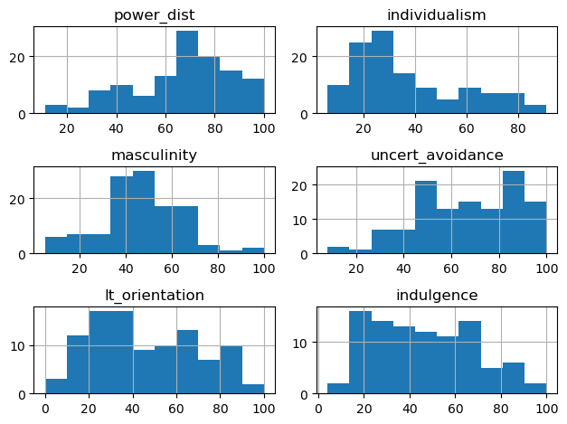

```python
ax = country_indices.hist()
plt.tight_layout()
```

I guess I expected the distributions to be Gaussian, but then again why should they be? Let's see if there are any patterns when we plot them on a map.

# Joining Everything Together

```python
world_culture = gp.GeoDataFrame(world.set_index('ISO_A3_EH').join(country_indices.set_index('iso_3166_alpha_3'), how='left'))
world_culture
```

| ISO_A3_EH | NAME_EN | SOVEREIGNT | geometry | country | power_dist | individualism | masculinity | uncert_avoidance | lt_orientation | indulgence |
| --- | --- | --- | --- | --- | --- | --- | --- | --- | --- | --- |
| FJI | Fiji | Fiji | MULTIPOLYGON (((180.00000 -16.06713, 180.00000... | Fiji | 78.0 | 14.0 | 46.0 | 48.0 | NaN | NaN |
| TZA | Tanzania | United Republic of Tanzania | POLYGON ((33.90371 -0.95000, 34.07262 -1.05982... | Tanzania | 70.0 | 25.0 | 40.0 | 50.0 | 34.0 | 38.0 |
| ESH | Western Sahara | Western Sahara | POLYGON ((-8.66559 27.65643, -8.66512 27.58948... | NaN | NaN | NaN | NaN | NaN | NaN | NaN |
| CAN | Canada | Canada | MULTIPOLYGON (((-122.84000 49.00000, -122.9742... | Canada | 39.0 | 80.0 | 52.0 | 48.0 | 36.0 | 68.0 |
| USA | United States of America | United States of America | MULTIPOLYGON (((-122.84000 49.00000, -120.0000... | United States | 40.0 | 91.0 | 62.0 | 46.0 | 26.0 | 68.0 |
| ... | ... | ... | ... | ... | ... | ... | ... | ... | ... | ... |
| MKD | North Macedonia | North Macedonia | POLYGON ((22.38053 42.32026, 22.88137 41.99930... | North Macedonia | 90.0 | 22.0 | 45.0 | 87.0 | 62.0 | 35.0 |
| SRB | Serbia | Republic of Serbia | POLYGON ((18.82982 45.90887, 18.82984 45.90888... | Serbia | 86.0 | 25.0 | 43.0 | 92.0 | 52.0 | 28.0 |
| MNE | Montenegro | Montenegro | POLYGON ((20.07070 42.58863, 19.80161 42.50009... | Montenegro | 88.0 | 24.0 | 48.0 | 90.0 | 75.0 | 20.0 |
| TTO | Trinidad and Tobago | Trinidad and Tobago | POLYGON ((-61.68000 10.76000, -61.10500 10.890... | Trinidad and Tobago | 47.0 | 16.0 | 58.0 | 55.0 | 13.0 | 80.0 |
| SSD | South Sudan | South Sudan | POLYGON ((30.83385 3.50917, 29.95350 4.17370, ... | NaN | NaN | NaN | NaN | NaN | NaN | NaN |

168 rows × 10 columns

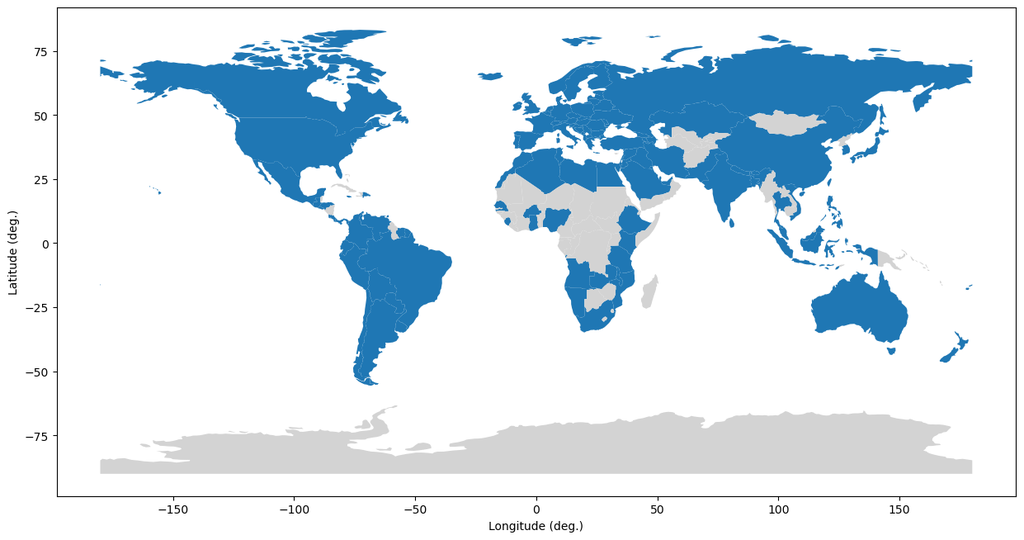

```python
# plotting the world
fig, ax = plt.subplots(1, 1, figsize=(15, 10))
world_culture['missing_lots'] = world_culture.isna().sum(axis=1)>2
_ = world_culture[world_culture.missing_lots==False].plot(ax=ax)
_ = world_culture[world_culture.missing_lots==True].plot(color='lightgrey', ax=ax)
_ = ax.set_xlabel('Longitude (deg.)')
_ = ax.set_ylabel('Latitude (deg.)')
```

It's worth noting what we're missing. Central Africa and large parts of central Asia have not been included in this analysis, speaking to the dearth of research performed in and on these countries.  
Furthermore, since North Korea is also not included in the analysis, the North Korea/South Korea border will not be considered.  
We will continue the analysis, but with the caveat that the dataset we're using is limited in scope.

## Plotting Cultural Dimensions

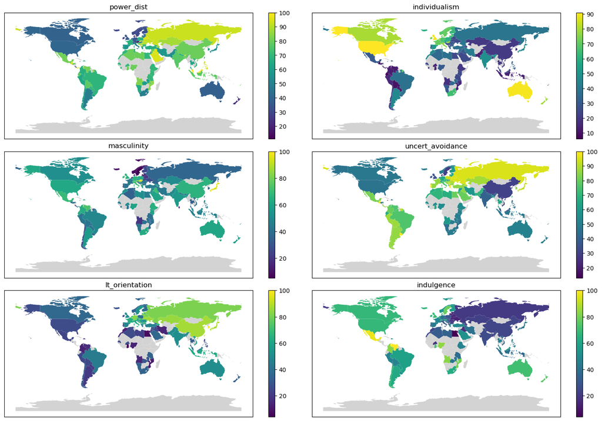

```python
fig, ax = plt.subplots(3, 2, figsize=(15, 10))
culture_dimensions = country_indices.columns[2:].tolist()
for col, ax in zip(culture_dimensions, ax.flatten()):
    _ = world_culture.plot(ax=ax, column=col, legend=True, missing_kwds={'color':'lightgrey'})
    ax.set_title(col)
    # hide lat/long cordinates
    ax.xaxis.set_visible(False)
    ax.yaxis.set_visible(False)
plt.tight_layout()
```

## Comments

So, there are a few themes here. Many dimensions exhibit an east-west gradient across the Eurasian landmass, with the individualism-collectivism axis being the most pronounced: China on one end being strongly collectivist and western Europe, particularly the UK, being strongly individualist. India is a slight outlier in this regard.

The analysis points towards individalism being strongly correlated with the influence of British colonilism, with the core anglosphere countries (UK, USA, Canada, Australia, New Zealand) all being in the top 10 most individualistic countries:

```python
country_indices.sort_values(by='individualism', ascending=False).head(10)
```

|  | country | iso_3166_alpha_3 | power_dist | individualism | masculinity | uncert_avoidance | lt_orientation | indulgence |
| --- | --- | --- | --- | --- | --- | --- | --- | --- |
| 113 | United States | USA | 40.0 | 91.0 | 62.0 | 46.0 | 26.0 | 68.0 |
| 5 | Australia | AUS | 38.0 | 90.0 | 61.0 | 51.0 | 51.0 | 71.0 |
| 112 | United Kingdom | GBR | 35.0 | 89.0 | 66.0 | 35.0 | 51.0 | 69.0 |
| 42 | Hungary | HUN | 46.0 | 80.0 | 88.0 | 82.0 | 58.0 | 31.0 |
| 73 | Netherlands | NLD | 38.0 | 80.0 | 14.0 | 53.0 | 67.0 | 68.0 |
| 18 | Canada | CAN | 39.0 | 80.0 | 52.0 | 48.0 | 36.0 | 68.0 |
| 74 | New Zealand | NZL | 22.0 | 79.0 | 58.0 | 49.0 | 33.0 | 75.0 |
| 50 | Italy | ITA | 50.0 | 76.0 | 70.0 | 75.0 | 61.0 | 30.0 |
| 10 | Belgium | BEL | 65.0 | 75.0 | 54.0 | 94.0 | 82.0 | 57.0 |
| 25 | Denmark | DNK | 18.0 | 74.0 | 16.0 | 23.0 | 35.0 | 70.0 |

The long-term/short-term orientation axis mirrors this to a lesser extent, with East Asian being dominated by long-term oriented countries such as South Korea, Taiwan, Japan, and China. The Americas, North Africa, and the Middle East exhibit the most short-term orientation, with Europe being more mixed between long-term oriented Germany, Belgium, Lithuania, and Estonia, and medium-term oriented countries.

```python
country_indices.sort_values(by='lt_orientation', ascending=False).head(10)
```

|  | country | iso_3166_alpha_3 | power_dist | individualism | masculinity | uncert_avoidance | lt_orientation | indulgence |
| --- | --- | --- | --- | --- | --- | --- | --- | --- |
| 56 | Korea, South | KOR | 60.0 | 18.0 | 39.0 | 85.0 | 100.0 | 29.0 |
| 104 | Taiwan | TWN | 58.0 | 17.0 | 45.0 | 69.0 | 93.0 | 49.0 |
| 52 | Japan | JPN | 54.0 | 46.0 | 95.0 | 92.0 | 88.0 | 42.0 |
| 20 | China | CHN | 80.0 | 20.0 | 66.0 | 30.0 | 87.0 | 24.0 |
| 110 | Ukraine | UKR | 92.0 | 25.0 | 27.0 | 95.0 | 86.0 | 14.0 |
| 54 | Kazakhstan | KAZ | 88.0 | 20.0 | 50.0 | 88.0 | 85.0 | 22.0 |
| 36 | Germany | DEU | 35.0 | 67.0 | 66.0 | 65.0 | 83.0 | 40.0 |
| 10 | Belgium | BEL | 65.0 | 75.0 | 54.0 | 94.0 | 82.0 | 57.0 |
| 61 | Lithuania | LTU | 42.0 | 60.0 | 19.0 | 65.0 | 82.0 | 16.0 |
| 30 | Estonia | EST | 40.0 | 60.0 | 30.0 | 60.0 | 82.0 | 16.0 |

```python
# Consider Correlations Between Dimensions
```

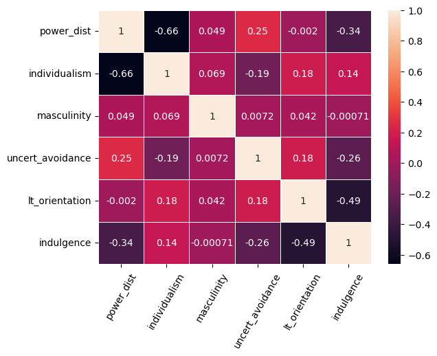

```python
# check coefficients of correlation
ax = sns.heatmap(country_indices[culture_dimensions].corr(method='pearson'), linewidths=.5, annot=True, fmt='.2g')
_=ax.set_xticklabels(ax.get_xticklabels(), rotation=60)
```

Notable features:

1. Individualism correlates negatively with power distance, which would indicate that a strongly individualistic culture would place more emphasis on egalitarianism.
2. Indulgence and long-term orientation are weakly negatively correlated. One may argue that these quantities are indeed related by definition, with indulgence being almost antithetical to delayed gratification.

However, none of the cultural dimensions correlate strongly enough to combine them or neglect of one them for the purposes of dimensionality reduction.

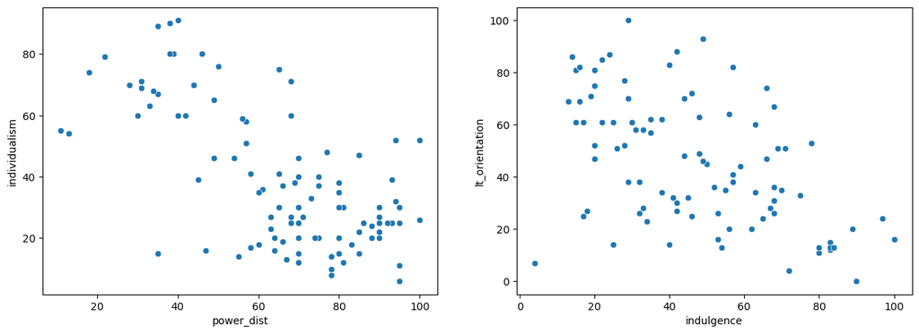

```python
fig, ax = plt.subplots(1, 2, figsize=(15, 5))
_ = sns.scatterplot(x = 'power_dist', y = 'individualism', data = country_indices, ax=ax[0])
_ = sns.scatterplot(x = 'indulgence', y = 'lt_orientation', data = country_indices, ax=ax[1])
```

# Calculating Culture Vectors

We're now in a position to start comparing culture between bordering cultures. First, join everything together such that we have an entry for each pair of bordering countries.

```python
world_culture_borders = world_culture.join(iso_borders.set_index('ISO_A3_EH_country1')).join(world_culture[culture_dimensions],
                                                                                             lsuffix='_country1',
                                                                                             rsuffix='_country2',
                                                                                             on='ISO_A3_EH_country2')
world_culture_borders.drop(['NAME_EN', 'SOVEREIGNT', 'geometry', 'country', 'missing_lots'], axis=1, inplace=True)
world_culture_borders.rename_axis('ISO_A3_EH_country1', inplace=True)
world_culture_borders.set_index('ISO_A3_EH_country2', append=True, inplace=True)
world_culture_borders.head()
```

| ISO_A3_EH_country1 | ISO_A3_EH_country2 | power_dist_country1 | individualism_country1 | masculinity_country1 | uncert_avoidance_country1 | lt_orientation_country1 | indulgence_country1 | NAME_EN_country1 | geometry_country1 | NAME_EN_country2 | geometry_country2 | geometry_border | power_dist_country2 | individualism_country2 | masculinity_country2 | uncert_avoidance_country2 | lt_orientation_country2 | indulgence_country2 |
| --- | --- | --- | --- | --- | --- | --- | --- | --- | --- | --- | --- | --- | --- | --- | --- | --- | --- | --- |
| FJI | NaN | 78.0 | 14.0 | 46.0 | 48.0 | NaN | NaN | Fiji | MULTIPOLYGON (((180.00000 -16.06713, 180.00000... | NaN | None | None | NaN | NaN | NaN | NaN | NaN | NaN |
| TZA | COD | 70.0 | 25.0 | 40.0 | 50.0 | 34.0 | 38.0 | Tanzania | POLYGON ((33.90371 -0.95000, 34.07262 -1.05982... | Democratic Republic of the Congo | POLYGON ((29.34000 -4.49998, 29.51999 -5.41998... | MULTILINESTRING ((30.740009731422095 -8.340005... | NaN | NaN | NaN | NaN | NaN | NaN |
|  | KEN | 70.0 | 25.0 | 40.0 | 50.0 | 34.0 | 38.0 | Tanzania | POLYGON ((33.90371 -0.95000, 34.07262 -1.05982... | Kenya | POLYGON ((39.20222 -4.67677, 37.76690 -3.67712... | MULTILINESTRING ((33.90371119710453 -0.9500000... | 70.0 | 25.0 | 60.0 | 50.0 | NaN | NaN |
|  | ZMB | 70.0 | 25.0 | 40.0 | 50.0 | 34.0 | 38.0 | Tanzania | POLYGON ((33.90371 -0.95000, 34.07262 -1.05982... | Zambia | POLYGON ((30.74001 -8.34001, 31.15775 -8.59458... | MULTILINESTRING ((32.75937544122132 -9.2305990... | 60.0 | 35.0 | 40.0 | 50.0 | 30.0 | 42.0 |
|  | MWI | 70.0 | 25.0 | 40.0 | 50.0 | 34.0 | 38.0 | Tanzania | POLYGON ((33.90371 -0.95000, 34.07262 -1.05982... | Malawi | POLYGON ((32.75938 -9.23060, 33.73972 -9.41715... | MULTILINESTRING ((34.55998904799935 -11.520020... | 70.0 | 30.0 | 40.0 | 50.0 | NaN | NaN |

## Define Culture Vector

For this project, we'll define a culture vector which will measure the magnitude of cultural difference between two countries, using the cultural indices. $${culture\_vector} = \begin{pmatrix} pdi \\ indv \\ masc \\ {unc\_av} \\ {lt\_ori} \\ indul \end{pmatrix}$$ Using this, we will calculate a $\Delta{culture\_vector}$ which represents the magnitude of the cultural difference between two countries. $$\Delta{culture\_vector}^2=\Delta{pdi}^2+\Delta{indv}^2+\Delta{masc}^2+\Delta{unc\_av}^2+\Delta{lt\_ori}^2+\Delta{indul}^2$$ In terms of code, define a function. Note that if any field is empty, it is simply ignored in the difference calculation.

```python
def calc_cult_vector_diff(args):
    culture_dimensions = ['power_dist','individualism','masculinity','uncert_avoidance','lt_orientation','indulgence']
    lsuffix = '_country1'
    rsuffix = '_country2'
    """
    vector = np.array([args['power_dist_country1']-args['power_dist_country2'],
                       args['individualism_country1']-args['individualism_country2'],
                       args['masculinity_country1']-args['masculinity_country2'],
                       args['uncert_avoidance_country1']-args['uncert_avoidance_country2'],
                       args['lt_orientation_country1']-args['lt_orientation_country2'],
                       args['indulgence_country1']-args['indulgence_country2']
                       ])
    """
    vector = args[[(dim+lsuffix) for dim in culture_dimensions]].values-args[[(dim+rsuffix) for dim in culture_dimensions]].values
    return pd.Series(data={'culture_vector_diff':np.sqrt(np.sum([np.square(x) for x in vector if not np.isnan(x)]))})
```

## Test Case: China

```python
china = world_culture_borders.loc['CHN']
china.head()
```

| ISO_A3_EH_country2 | power_dist_country1 | individualism_country1 | masculinity_country1 | uncert_avoidance_country1 | lt_orientation_country1 | indulgence_country1 | NAME_EN_country1 | geometry_country1 | NAME_EN_country2 | geometry_country2 | geometry_border | power_dist_country2 | individualism_country2 | masculinity_country2 | uncert_avoidance_country2 | lt_orientation_country2 | indulgence_country2 |
| --- | --- | --- | --- | --- | --- | --- | --- | --- | --- | --- | --- | --- | --- | --- | --- | --- | --- |
| KAZ | 80.0 | 20.0 | 66.0 | 30.0 | 87.0 | 24.0 | People's Republic of China | MULTIPOLYGON (((109.47521 18.19770, 108.65521 ... | Kazakhstan | POLYGON ((87.35997 49.21498, 86.59878 48.54918... | MULTILINESTRING ((80.2599902688853 42.34999929... | 88.0 | 20.0 | 50.0 | 88.0 | 85.0 | 22.0 |
| RUS | 80.0 | 20.0 | 66.0 | 30.0 | 87.0 | 24.0 | People's Republic of China | MULTIPOLYGON (((109.47521 18.19770, 108.65521 ... | Russia | MULTIPOLYGON (((178.72530 71.09880, 180.00000 ... | MULTILINESTRING ((87.35997033076265 49.2149807... | 93.0 | 39.0 | 36.0 | 95.0 | 81.0 | 20.0 |
| LAO | 80.0 | 20.0 | 66.0 | 30.0 | 87.0 | 24.0 | People's Republic of China | MULTIPOLYGON (((109.47521 18.19770, 108.65521 ... | Laos | POLYGON ((107.38273 14.20244, 106.49637 14.570... | MULTILINESTRING ((102.17043582561358 22.464753... | NaN | NaN | NaN | NaN | NaN | NaN |
| MMR | 80.0 | 20.0 | 66.0 | 30.0 | 87.0 | 24.0 | People's Republic of China | MULTIPOLYGON (((109.47521 18.19770, 108.65521 ... | Myanmar | POLYGON ((100.11599 20.41785, 99.54331 20.1866... | MULTILINESTRING ((101.18000532430754 21.436572... | NaN | NaN | NaN | NaN | NaN | NaN |
| VNM | 80.0 | 20.0 | 66.0 | 30.0 | 87.0 | 24.0 | People's Republic of China | MULTIPOLYGON (((109.47521 18.19770, 108.65521 ... | Vietnam | POLYGON ((104.33433 10.48654, 105.19991 10.889... | MULTILINESTRING ((108.05018029178294 21.552379... | 70.0 | 20.0 | 40.0 | 30.0 | 57.0 | 35.0 |

```python
china.apply(lambda x: calc_cult_vector_diff(x), axis=1)
```

| ISO_A3_EH_country2 | culture_vector_diff |
| --- | --- |
| KAZ | 60.761830 |
| RUS | 75.544689 |
| LAO | 0.000000 |
| MMR | 0.000000 |
| VNM | 42.391037 |
| PRK | 0.000000 |
| MNG | 0.000000 |
| IND | 47.885280 |
| BTN | 48.785244 |
| NPL | 33.181320 |
| PAK | 62.337790 |
| AFG | 0.000000 |
| TJK | 0.000000 |
| KGZ | 0.000000 |

Looks promising! We've already noted the missing data for countries in Central Asia so no surprises there, but the methods works so let's do it for all countries.

## Global Culture Vectors

```python
cult_diff_vector = world_culture_borders.apply(lambda x: calc_cult_vector_diff(x), axis=1)
world_culture_borders = world_culture_borders.join(cult_diff_vector, how='inner')
# drop NaN values, where no cultural data exists for country2
world_culture_borders = world_culture_borders.drop(world_culture_borders[world_culture_borders.culture_vector_diff==0].index)
world_culture_borders
```

| ISO_A3_EH_country1 | ISO_A3_EH_country2 | power_dist_country1 | individualism_country1 | masculinity_country1 | uncert_avoidance_country1 | lt_orientation_country1 | indulgence_country1 | NAME_EN_country1 | geometry_country1 | NAME_EN_country2 | geometry_country2 | geometry_border | power_dist_country2 | individualism_country2 | masculinity_country2 | uncert_avoidance_country2 | lt_orientation_country2 | indulgence_country2 | culture_vector_diff |
| --- | --- | --- | --- | --- | --- | --- | --- | --- | --- | --- | --- | --- | --- | --- | --- | --- | --- | --- | --- |
| TZA | KEN | 70.0 | 25.0 | 40.0 | 50.0 | 34.0 | 38.0 | Tanzania | POLYGON ((33.90371 -0.95000, 34.07262 -1.05982... | Kenya | POLYGON ((39.20222 -4.67677, 37.76690 -3.67712... | MULTILINESTRING ((33.90371119710453 -0.9500000... | 70.0 | 25.0 | 60.0 | 50.0 | NaN | NaN | 20.000000 |
|  | ZMB | 70.0 | 25.0 | 40.0 | 50.0 | 34.0 | 38.0 | Tanzania | POLYGON ((33.90371 -0.95000, 34.07262 -1.05982... | Zambia | POLYGON ((30.74001 -8.34001, 31.15775 -8.59458... | MULTILINESTRING ((32.75937544122132 -9.2305990... | 60.0 | 35.0 | 40.0 | 50.0 | 30.0 | 42.0 | 15.231546 |
|  | MWI | 70.0 | 25.0 | 40.0 | 50.0 | 34.0 | 38.0 | Tanzania | POLYGON ((33.90371 -0.95000, 34.07262 -1.05982... | Malawi | POLYGON ((32.75938 -9.23060, 33.73972 -9.41715... | MULTILINESTRING ((34.55998904799935 -11.520020... | 70.0 | 30.0 | 40.0 | 50.0 | NaN | NaN | 5.000000 |
|  | MOZ | 70.0 | 25.0 | 40.0 | 50.0 | 34.0 | 38.0 | Tanzania | POLYGON ((33.90371 -0.95000, 34.07262 -1.05982... | Mozambique | POLYGON ((34.55999 -11.52002, 35.31240 -11.439... | MULTILINESTRING ((40.316586229110854 -10.31709... | 85.0 | 15.0 | 38.0 | 44.0 | 11.0 | 80.0 | 51.555795 |
| CAN | USA | 39.0 | 80.0 | 52.0 | 48.0 | 36.0 | 68.0 | Canada | MULTIPOLYGON (((-122.84000 49.00000, -122.9742... | United States of America | MULTIPOLYGON (((-122.84000 49.00000, -120.0000... | MULTILINESTRING ((-130.53610895273684 54.80275... | 40.0 | 91.0 | 62.0 | 46.0 | 26.0 | 68.0 | 18.055470 |
| ... | ... | ... | ... | ... | ... | ... | ... | ... | ... | ... | ... | ... | ... | ... | ... | ... | ... | ... | ... |
| SRB | MNE | 86.0 | 25.0 | 43.0 | 92.0 | 52.0 | 28.0 | Serbia | POLYGON ((18.82982 45.90887, 18.82984 45.90888... | Montenegro | POLYGON ((20.07070 42.58863, 19.80161 42.50009... | MULTILINESTRING ((20.257580000000075 42.812750... | 88.0 | 24.0 | 48.0 | 90.0 | 75.0 | 20.0 | 25.039968 |
| MNE | ALB | 88.0 | 24.0 | 48.0 | 90.0 | 75.0 | 20.0 | Montenegro | POLYGON ((20.07070 42.58863, 19.80161 42.50009... | Albania | POLYGON ((21.02004 40.84273, 20.99999 40.58000... | MULTILINESTRING ((20.070700000000045 42.588630... | 90.0 | 20.0 | 80.0 | 70.0 | 61.0 | 15.0 | 40.804412 |
|  | HRV | 88.0 | 24.0 | 48.0 | 90.0 | 75.0 | 20.0 | Montenegro | POLYGON ((20.07070 42.58863, 19.80161 42.50009... | Croatia | POLYGON ((16.56481 46.50375, 16.88252 46.38063... | LINESTRING (18.45001688302086 42.4799922453121... | 73.0 | 33.0 | 40.0 | 80.0 | 58.0 | 33.0 | 30.463092 |
|  | BIH | 88.0 | 24.0 | 48.0 | 90.0 | 75.0 | 20.0 | Montenegro | POLYGON ((20.07070 42.58863, 19.80161 42.50009... | Bosnia and Herzegovina | POLYGON ((18.56000 42.65000, 17.67492 43.02856... | MULTILINESTRING ((18.559999999999945 42.649999... | 90.0 | 22.0 | 48.0 | 87.0 | 70.0 | 44.0 | 24.859606 |
|  | SRB | 88.0 | 24.0 | 48.0 | 90.0 | 75.0 | 20.0 | Montenegro | POLYGON ((20.07070 42.58863, 19.80161 42.50009... | Serbia | POLYGON ((18.82982 45.90887, 18.82984 45.90888... | MULTILINESTRING ((19.218519999999955 43.523840... | 86.0 | 25.0 | 43.0 | 92.0 | 52.0 | 28.0 | 25.039968 |

338 rows × 18 columns

# Plotting Borders

## Steepest Borders

We are now in a position to actually determine the steepest border between countries.

```python
# display only every other entry to avoid double-entries
world_culture_borders[['culture_vector_diff']].sort_values(by='culture_vector_diff', ascending=False)[::2].head(20)
```

| ISO_A3_EH_country1 | ISO_A3_EH_country2 | culture_vector_diff |
| --- | --- | --- |
| NOR | RUS | 104.374326 |
| AUT | SVK | 101.222527 |
| UKR | HUN | 100.518655 |
| FIN | RUS | 93.755000 |
| SVN | AUT | 93.026878 |
|  | HUN | 92.741576 |
| UKR | SVK | 91.296221 |
| DEU | DNK | 88.351570 |
| MEX | USA | 87.132084 |
| SRB | HUN | 82.431790 |
| ROU | HUN | 82.298238 |
| ITA | SVN | 77.974355 |
| BLR | POL | 77.064908 |
| LVA | BLR | 76.935038 |
| ISR | LBN | 76.817967 |
| CHN | RUS | 75.544689 |
| UKR | POL | 75.518210 |
| POL | SVK | 75.299402 |
| LTU | POL | 74.766303 |
| SYR | ISR | 73.348483 |

There we are: the sharpest land-border in the world is the Russia-Norway border. Despite being a relatively long border at around 200 km, it is very scarcely populated. Furthermore, the centers of gravity of both countries are of course many kilometers away from this border, with the closest city with a population above 50,000 (Murmansk) in Russia being 110 km from the border, and the closest Norwegian city with a population above 50,000 (Tromso) being 430 km away.

We would intuit that factors influencing this sharpness is the population density close to the border, along with the size of the country; a smaller country with a high population density close to border might have been conducive the high volumes of cultural exchange between the countries.

Regardless, it perhaps not a surprise that the sharpest border according to this analysis is between an EEC country and the former USSR, two economic and societal orders which differ significantly. As we can see, Russia also has a very sharp border with Finland, another Nordic country which indeed fought a hot war with Russia in the years 1939-40.

### Plotting Borders

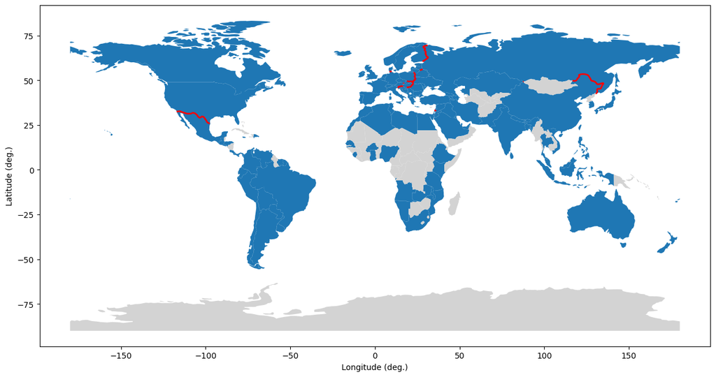

```python
from shapely.plotting import plot_line

steepest_borders = world_culture_borders.sort_values(by='culture_vector_diff', ascending=False)[::2].head(20)
fig, ax = plt.subplots(1, figsize=(15, 10))
_ = world_culture[world_culture.missing_lots==False].plot(ax=ax)
_ = world_culture[world_culture.missing_lots==True].plot(color='lightgrey', ax=ax)

_ = steepest_borders.apply(lambda x: plot_line(x.geometry_border, ax=ax, color='r', add_points=False), axis=1)
_ = ax.set_xlabel('Longitude (deg.)')
_ = ax.set_ylabel('Latitude (deg.)')
```

```python
fig.savefig("global_map_borders.svg", format = 'svg', dpi=300, bbox_inches='tight')
```

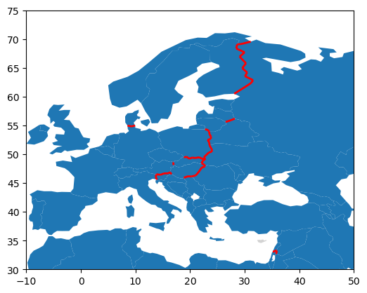

```python
fig, ax = plt.subplots(1)
_ = world_culture[world_culture.missing_lots==False].plot(ax=ax)
_ = world_culture[world_culture.missing_lots==True].plot(color='lightgrey', ax=ax)
_ = steepest_borders.apply(lambda x: plot_line(x.geometry_border, ax=ax, color='r', add_points=False), axis=1)
_ = ax.set_xlim(-10, 50)
_ = ax.set_ylim(30, 75)
```

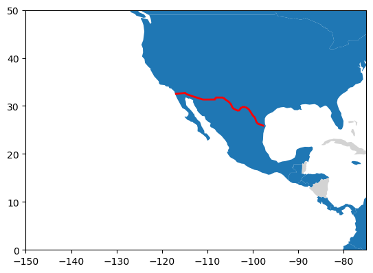

```python
fig, ax = plt.subplots(1)
_ = world_culture[world_culture.missing_lots==False].plot(ax=ax)
_ = world_culture[world_culture.missing_lots==True].plot(color='lightgrey', ax=ax)
_ = steepest_borders.apply(lambda x: plot_line(x.geometry_border, ax=ax, color='r', add_points=False), axis=1)
_ = ax.set_xlim(-150, -75)
_ = ax.set_ylim(0, 50)
```

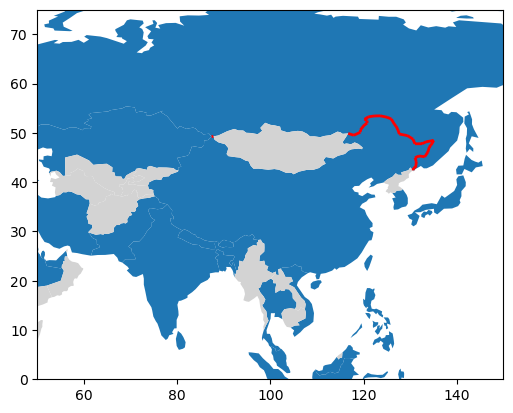

```python
fig, ax = plt.subplots(1)
_ = world_culture[world_culture.missing_lots==False].plot(ax=ax)
_ = world_culture[world_culture.missing_lots==True].plot(color='lightgrey', ax=ax)
_ = steepest_borders.apply(lambda x: plot_line(x.geometry_border, ax=ax, color='r', add_points=False), axis=1)
_ = ax.set_xlim(50, 150)
_ = ax.set_ylim(0, 75)
```

## Shallowest Borders

Conversely, we can look at the shallowest borders, i.e. cultures with the most similarities.

```python
world_culture_borders[['culture_vector_diff']].sort_values(by='culture_vector_diff', ascending=True)[::2].head(20)
```

| ISO_A3_EH_country1 | ISO_A3_EH_country2 | culture_vector_diff |
| --- | --- | --- |
| AZE | ARM | 3.000000 |
| MWI | TZA | 5.000000 |
| QAT | SAU | 5.385165 |
| KEN | ETH | 8.660254 |
| BLR | UKR | 9.165151 |
| ZMB | NAM | 10.000000 |
| SRB | ROU | 10.488088 |
| MWI | ZMB | 11.180340 |
| ARE | SAU | 11.180340 |
| TUN | DZA | 13.228757 |
| PRY | BOL | 14.177447 |
| MKD | SRB | 14.247807 |
| PER | BOL | 15.231546 |
| TZA | ZMB | 15.231546 |
| TUN | LBY | 17.233688 |
| DZA | LBY | 17.748239 |
| COL | ECU | 17.776389 |
| CAN | USA | 18.055470 |
| RUS | UKR | 18.411953 |
| LVA | LTU | 19.646883 |

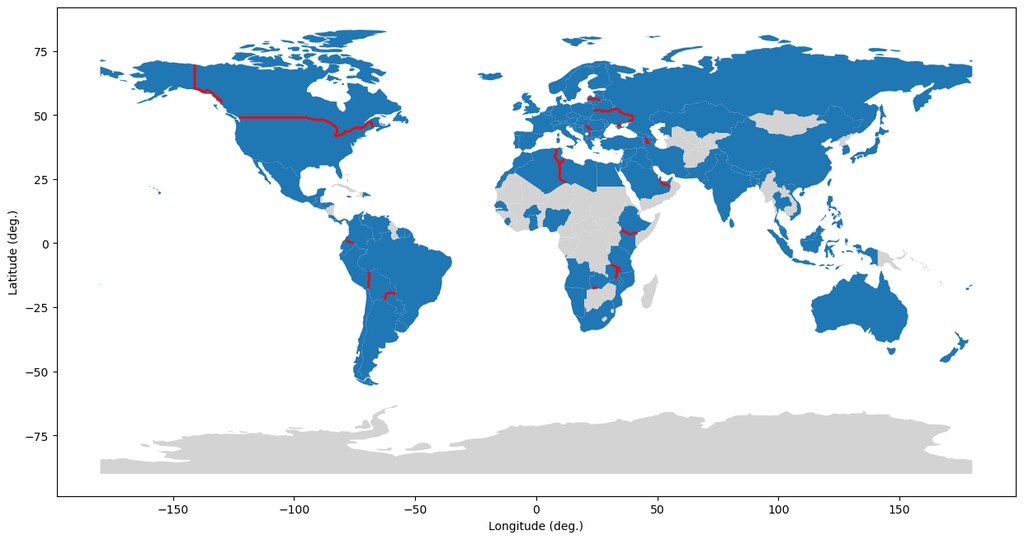

```python
shallowest_borders = world_culture_borders.sort_values(by='culture_vector_diff', ascending=True)[::2].head(20)
fig, ax = plt.subplots(1, figsize=(15, 10))
_ = world_culture[world_culture.missing_lots==False].plot(ax=ax)
_ = world_culture[world_culture.missing_lots==True].plot(color='lightgrey', ax=ax)

_ = shallowest_borders.apply(lambda x: plot_line(x.geometry_border, ax=ax, color='r', add_points=False), axis=1)
_ = ax.set_xlabel('Longitude (deg.)')
_ = ax.set_ylabel('Latitude (deg.)')
```

# Summary

### Cluster Analysis

```python
from sklearn.cluster import KMeans
```

```python
df = world_culture[culture_dimensions].dropna()
df.describe()
```

|  | power_dist | individualism | masculinity | uncert_avoidance | lt_orientation | indulgence |
| --- | --- | --- | --- | --- | --- | --- |
| count | 88.000000 | 88.000000 | 88.000000 | 88.000000 | 88.00000 | 88.000000 |
| mean | 64.954545 | 40.250000 | 47.806818 | 69.204545 | 45.87500 | 45.443182 |
| std | 21.158900 | 22.429071 | 18.722325 | 19.945419 | 24.45113 | 22.338492 |
| min | 11.000000 | 10.000000 | 5.000000 | 23.000000 | 4.00000 | 4.000000 |
| 25% | 49.000000 | 22.000000 | 39.750000 | 51.000000 | 25.75000 | 27.500000 |
| 50% | 68.000000 | 32.500000 | 47.000000 | 70.000000 | 44.50000 | 44.000000 |
| 75% | 80.250000 | 60.000000 | 60.000000 | 86.250000 | 63.25000 | 63.000000 |
| max | 100.000000 | 91.000000 | 100.000000 | 100.000000 | 100.00000 | 100.000000 |

```python
kmeans = KMeans(n_clusters = 5)
kmeans.fit(df[['power_dist', 'individualism']])
y_kmeans = kmeans.predict(df[['power_dist', 'individualism']])
```

```python
centers = kmeans.cluster_centers_
```

```python
np.array(centers).shape
```

```
(5, 2)
```

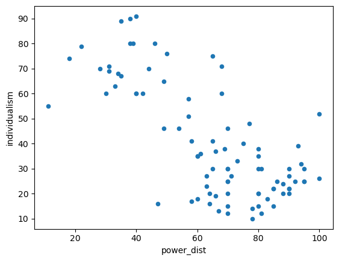

```python
df.plot(kind='scatter', x = 'power_dist', y = 'individualism')
```

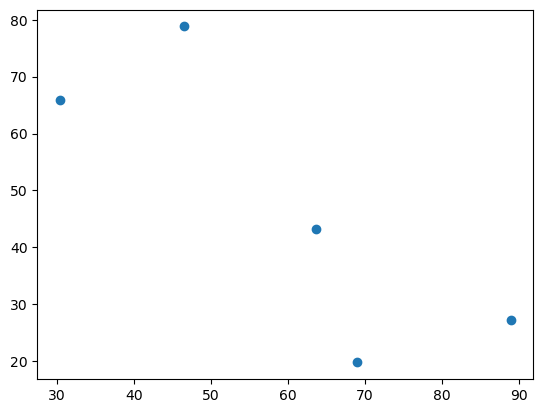

```python
plt.scatter(centers[:, 0], centers[:, 1])
```